# ch08_03_Automl_spaceship_titanic_2207

### 실전 데이터 분석 - Spaceship Titanic 데이터 셋

- pycaret를 활용한 automl 실습해 보기

### 학습 내용

- 1. kaggle 데이터 셋 가져오기
- 1. 라이브러리 및 데이터 셋 가져오기
- 1. 데이터 EDA
- 1. 데이터 전처리
- 1. 모델 구축 및 예측

### 목차

01. kaggle 데이터 셋 가져오기  
02. 라이브러리 준비 및 데이터 셋 가져오기  
03. 데이터 EDA  
04. 데이터 전처리  
05. 모델 구축 및 예측

### 01. kaggle 데이터 셋 가져오기

목차로 이동하기

### 대회 개요

- 대회 : https://www.kaggle.com/competitions/spaceship-titanic
- 참조 노트북 : https://www.kaggle.com/code/arootda/pycaret-visualization-optimization-0-81

### 사전 준비

- 개발 환경 : google colab CPU (같은 코드로 GPU 가능 - 2022/07)
- kaggle 설치
- kaggle의 API Token 다운로드
  - 본인 Account페이지 -
  - API - Create New API Token 선택 후, 파일 다운로드
  - 파일(kaggle.json)을 코랩에 업로드
- 대회 : https://www.kaggle.com/competitions/spaceship-titanic/data
- data를 선택 후, 다운로드 cmd 확인
- 대회 참여을 선택 후, 'I Understand and Accept'가 먼저 수행되어야 한다.

### 구글 드라이브에서 kaggle.json 가져오기 - 방법1

- 구글 드라이브를 연결 후, Colab으로 복사해서 가져오기

  ```
  from google.colab import drive
  drive.mount('/content/drive')
  ```

### 설치

```
!pip install kaggle --upgrade
```

### 구글 드라이브에서 kaggle.json 가져오기 - 방법2

### kaggle.json 파일 이동

```
!mkdir -p ~/.kaggle
!cp kaggle.json ~/.kaggle/
!chmod 600 ~/.kaggle/kaggle.json
!ls -l kaggle.json
```

### 필요한 데이터 셋 가져오기

```
!kaggle competitions download -c spaceship-titanic
```

### 데이터 확인

```
# 파일 확인
!ls -l

# 압축 풀기
!unzip [파일명]

# 파일 확인
!ls -l
```

```python
# 구글 드라이브 연결
from google.colab import drive
drive.mount('/content/drive')
```

```python
# kaggle 패키지 설치
!pip install kaggle --upgrade
```

```python
### 방법1 - 구글 드라이브에서 kaggle.json을 가져오기
!ls -l drive/MyDrive/
!cp drive/MyDrive/kaggle.json /content/
!ls -l /content/
```

```
total 902
drwx------ 2 root root   4096 Aug  8  2020  탈잉
drwx------ 2 root root   4096 Sep  9  2020  유튜브
drwx------ 2 root root   4096 Sep  1  2020  방송통신대학교_파이썬기본
-rw------- 1 root root  18644 Sep 25  2020  1_7_내장함수.ipynb
drwx------ 2 root root   4096 Aug  3  2020  책번역_20200803
drwx------ 2 root root   4096 May  8  2020  빅데이터4기_서울IT
drwx------ 2 root root   4096 Sep 20  2020  AI이노베이션
drwx------ 2 root root   4096 Jun 17  2020  Burj_Khalifa
drwx------ 2 root root   4096 Jan  3  2020 'Colab Notebooks'
drwx------ 2 root root   4096 Jun 17  2020  Colosseum
drwx------ 2 root root   4096 Jul 20  2020  dataset
-rw------- 1 root root  10842 Nov 18  2020  gan_deep_dream.ipynb
drwx------ 2 root root   4096 May  1  2021  jds
-rw------- 1 root root 398659 Mar 24  2021  샘플이미지.jpg
-rw------- 1 root root     67 Jun 28 14:57  kaggle.json
-rw------- 1 root root 444540 Jan 26  2021  서약.png
drwx------ 2 root root   4096 Jun 17  2020  test
total 12
drwx------ 5 root root 4096 Jun 29 09:23 drive
-rw------- 1 root root   67 Jun 29 09:23 kaggle.json
drwxr-xr-x 1 root root 4096 Jun 15 13:42 sample_data
```

```python
# kaggle.json 업로드 후,
!mkdir -p ~/.kaggle
!cp kaggle.json ~/.kaggle/
!chmod 600 ~/.kaggle/kaggle.json
!ls -l kaggle.json
```

```
-rw------- 1 root root 67 Jun 29 09:23 kaggle.json
```

```python
# kaggle API를 이용하여 데이터 셋 다운로드 하기
!kaggle competitions download -c spaceship-titanic
```

```
Downloading spaceship-titanic.zip to /content
  0% 0.00/299k [00:00<?, ?B/s]
100% 299k/299k [00:00<00:00, 83.1MB/s]
```

```python
# 파일 확인
!ls -l

# 압축 풀기
!unzip spaceship-titanic.zip

!ls -l
```

```
total 312
drwx------ 5 root root   4096 Jun 29 09:23 drive
-rw------- 1 root root     67 Jun 29 09:23 kaggle.json
drwxr-xr-x 1 root root   4096 Jun 15 13:42 sample_data
-rw-r--r-- 1 root root 306403 Jun 29 09:23 spaceship-titanic.zip
Archive:  spaceship-titanic.zip
  inflating: sample_submission.csv
  inflating: test.csv
  inflating: train.csv
total 1524
drwx------ 5 root root   4096 Jun 29 09:23 drive
-rw------- 1 root root     67 Jun 29 09:23 kaggle.json
drwxr-xr-x 1 root root   4096 Jun 15 13:42 sample_data
-rw-r--r-- 1 root root  59902 Feb 11 14:02 sample_submission.csv
-rw-r--r-- 1 root root 306403 Jun 29 09:23 spaceship-titanic.zip
-rw-r--r-- 1 root root 372487 Feb 11 14:02 test.csv
-rw-r--r-- 1 root root 805421 Feb 11 14:02 train.csv
```

### 02. 라이브러리 준비 및 데이터 셋 가져오기

목차로 이동하기

```python
!pip install pycaret==2.3.10
```

[output not shown]

[output cut: 55 more lines]

[output not shown]

```python
import pycaret
from pycaret.classification import *
from IPython.display import Image, display
import pandas as pd
import matplotlib.pyplot as plt
import seaborn as sns
```

[output not shown]

- 에러 발생시

```
from pycaret.classification import *

ImportError: Missing optional dependency 'Jinja2'. DataFrame.style requires jinja2. Use pip or conda to install Jinja2.
```

### 해결 시도

- 관련 패키지를 설치

  ```
  pip3 install jinja2==3.0.1
  pip install markupsafe==2.0.1
  ```

```python
!pip install jinja2==3.0.1
!pip install markupsafe==2.0.1
```

[output not shown]

### 적용을 위해 재기동 후, 실행

```python
# 메모리 정리
# gc.collect() : 가비지 컬렉션을 수행
import gc
gc.collect()
```

```
128
```

```python
import pycaret
from pycaret.classification import *
from IPython.display import Image, display
import pandas as pd
import matplotlib.pyplot as plt
import seaborn as sns

print(pycaret.__version__)
print(sns.__version__)
print(pd.__version__)
```

```
2.3.10
0.11.2
1.3.5
```

```python
# 기본 라이브러리
import numpy as np
import pandas as pd
import matplotlib.pyplot as plt
import seaborn as sns
import warnings
warnings.filterwarnings('ignore')

# 머신러닝 관련 라이브러리
from sklearn.impute import SimpleImputer
from sklearn.metrics import accuracy_score
from sklearn.preprocessing import LabelEncoder
from sklearn.model_selection import StratifiedKFold, train_test_split

# 시각화 관련 라이브러리
import plotly.express as px
from plotly.subplots import make_subplots
import plotly.graph_objects as go

PALETTE=['lightcoral', 'lightskyblue', 'gold', 'sandybrown', 'navajowhite',
        'khaki', 'lightslategrey', 'turquoise', 'rosybrown', 'thistle', 'pink']

sns.set_palette(PALETTE)
BACKCOLOR = '#f6f5f5'

from IPython.core.display import HTML
```

```python
def multi_table(table_list):
    return HTML(
        f"<table><tr> {''.join(['<td>' + table._repr_html_() + '</td>' for table in table_list])} </tr></table>")
```

```python
# 데이터 불러오기
train = pd.read_csv("train.csv")
test = pd.read_csv("test.csv")
submission = pd.read_csv("sample_submission.csv")

all_data = pd.concat([train, test], axis=0)
```

### 03. 데이터 EDA

목차로 이동하기

```python
all_data.head(10).style.background_gradient()
```

|  | PassengerId | HomePlanet | CryoSleep | Cabin | Destination | Age | VIP | RoomService | FoodCourt | ShoppingMall | Spa | VRDeck | Name | Transported |
| --- | --- | --- | --- | --- | --- | --- | --- | --- | --- | --- | --- | --- | --- | --- |
| 0 | 0001_01 | Europa | False | B/0/P | TRAPPIST-1e | 39.000000 | False | 0.000000 | 0.000000 | 0.000000 | 0.000000 | 0.000000 | Maham Ofracculy | False |
| 1 | 0002_01 | Earth | False | F/0/S | TRAPPIST-1e | 24.000000 | False | 109.000000 | 9.000000 | 25.000000 | 549.000000 | 44.000000 | Juanna Vines | True |
| 2 | 0003_01 | Europa | False | A/0/S | TRAPPIST-1e | 58.000000 | True | 43.000000 | 3576.000000 | 0.000000 | 6715.000000 | 49.000000 | Altark Susent | False |
| 3 | 0003_02 | Europa | False | A/0/S | TRAPPIST-1e | 33.000000 | False | 0.000000 | 1283.000000 | 371.000000 | 3329.000000 | 193.000000 | Solam Susent | False |
| 4 | 0004_01 | Earth | False | F/1/S | TRAPPIST-1e | 16.000000 | False | 303.000000 | 70.000000 | 151.000000 | 565.000000 | 2.000000 | Willy Santantines | True |
| 5 | 0005_01 | Earth | False | F/0/P | PSO J318.5-22 | 44.000000 | False | 0.000000 | 483.000000 | 0.000000 | 291.000000 | 0.000000 | Sandie Hinetthews | True |
| 6 | 0006_01 | Earth | False | F/2/S | TRAPPIST-1e | 26.000000 | False | 42.000000 | 1539.000000 | 3.000000 | 0.000000 | 0.000000 | Billex Jacostaffey | True |
| 7 | 0006_02 | Earth | True | G/0/S | TRAPPIST-1e | 28.000000 | False | 0.000000 | 0.000000 | 0.000000 | 0.000000 | nan | Candra Jacostaffey | True |
| 8 | 0007_01 | Earth | False | F/3/S | TRAPPIST-1e | 35.000000 | False | 0.000000 | 785.000000 | 17.000000 | 216.000000 | 0.000000 | Andona Beston | True |
| 9 | 0008_01 | Europa | True | B/1/P | 55 Cancri e | 14.000000 | False | 0.000000 | 0.000000 | 0.000000 | 0.000000 | 0.000000 | Erraiam Flatic | True |

```python
print(f'train size : {train.shape[0]} x {train.shape[1]}')
print(f'test size : {test.shape[0]} x {test.shape[1]}')
print(f'total size : {all_data.shape[0]} x {all_data.shape[1]}')
```

```
train size : 8693 x 14
test size : 4277 x 13
total size : 12970 x 14
```

```python
display(all_data.columns)
print()
display(all_data.dtypes)
print()
display(all_data.info())
```

```
Index(['PassengerId', 'HomePlanet', 'CryoSleep', 'Cabin', 'Destination', 'Age',
       'VIP', 'RoomService', 'FoodCourt', 'ShoppingMall', 'Spa', 'VRDeck',
       'Name', 'Transported'],
      dtype='object')
```

```
PassengerId      object
HomePlanet       object
CryoSleep        object
Cabin            object
Destination      object
Age             float64
VIP              object
RoomService     float64
FoodCourt       float64
ShoppingMall    float64
Spa             float64
VRDeck          float64
Name             object
Transported      object
dtype: object
```

```
<class 'pandas.core.frame.DataFrame'>
Int64Index: 12970 entries, 0 to 4276
Data columns (total 14 columns):
 #   Column        Non-Null Count  Dtype
---  ------        --------------  -----
 0   PassengerId   12970 non-null  object
 1   HomePlanet    12682 non-null  object
 2   CryoSleep     12660 non-null  object
 3   Cabin         12671 non-null  object
 4   Destination   12696 non-null  object
 5   Age           12700 non-null  float64
 6   VIP           12674 non-null  object
 7   RoomService   12707 non-null  float64
 8   FoodCourt     12681 non-null  float64
 9   ShoppingMall  12664 non-null  float64
 10  Spa           12686 non-null  float64
 11  VRDeck        12702 non-null  float64
 12  Name          12676 non-null  object
 13  Transported   8693 non-null   object
dtypes: float64(6), object(8)
memory usage: 1.5+ MB
```

```
None
```

```python
nominal_vars = ['HomePlanet', 'CryoSleep', 'Cabin', 'Desination', 'VIP', 'Name']
continuous_vars = ['Age', 'RoomService', 'FoodCourt', 'ShoppingMall', 'Spa', 'VRDeck']
target = 'Transported'
```

```python
train_st = train[continuous_vars].describe()
test_st = test[continuous_vars].describe()
all_st = all_data[continuous_vars].describe()

multi_table([all_st, train_st, test_st])
```

|  | Age | RoomService | FoodCourt | ShoppingMall | Spa | VRDeck |
| --- | --- | --- | --- | --- | --- | --- |
| count | 12700.000000 | 12707.000000 | 12681.000000 | 12664.000000 | 12686.000000 | 12702.000000 |
| mean | 28.771969 | 222.897852 | 451.961675 | 174.906033 | 308.476904 | 306.789482 |
| std | 14.387261 | 647.596664 | 1584.370747 | 590.558690 | 1130.279641 | 1180.097223 |
| min | 0.000000 | 0.000000 | 0.000000 | 0.000000 | 0.000000 | 0.000000 |
| 25% | 19.000000 | 0.000000 | 0.000000 | 0.000000 | 0.000000 | 0.000000 |
| 50% | 27.000000 | 0.000000 | 0.000000 | 0.000000 | 0.000000 | 0.000000 |
| 75% | 38.000000 | 49.000000 | 77.000000 | 29.000000 | 57.000000 | 42.000000 |
| max | 79.000000 | 14327.000000 | 29813.000000 | 23492.000000 | 22408.000000 | 24133.000000 |

|  | Age | RoomService | FoodCourt | ShoppingMall | Spa | VRDeck |
| --- | --- | --- | --- | --- | --- | --- |
| count | 8514.000000 | 8512.000000 | 8510.000000 | 8485.000000 | 8510.000000 | 8505.000000 |
| mean | 28.827930 | 224.687617 | 458.077203 | 173.729169 | 311.138778 | 304.854791 |
| std | 14.489021 | 666.717663 | 1611.489240 | 604.696458 | 1136.705535 | 1145.717189 |
| min | 0.000000 | 0.000000 | 0.000000 | 0.000000 | 0.000000 | 0.000000 |
| 25% | 19.000000 | 0.000000 | 0.000000 | 0.000000 | 0.000000 | 0.000000 |
| 50% | 27.000000 | 0.000000 | 0.000000 | 0.000000 | 0.000000 | 0.000000 |
| 75% | 38.000000 | 47.000000 | 76.000000 | 27.000000 | 59.000000 | 46.000000 |
| max | 79.000000 | 14327.000000 | 29813.000000 | 23492.000000 | 22408.000000 | 24133.000000 |

|  | Age | RoomService | FoodCourt | ShoppingMall | Spa | VRDeck |
| --- | --- | --- | --- | --- | --- | --- |
| count | 4186.000000 | 4195.000000 | 4171.000000 | 4179.000000 | 4176.000000 | 4197.000000 |
| mean | 28.658146 | 219.266269 | 439.484296 | 177.295525 | 303.052443 | 310.710031 |
| std | 14.179072 | 607.011289 | 1527.663045 | 560.821123 | 1117.186015 | 1246.994742 |
| min | 0.000000 | 0.000000 | 0.000000 | 0.000000 | 0.000000 | 0.000000 |
| 25% | 19.000000 | 0.000000 | 0.000000 | 0.000000 | 0.000000 | 0.000000 |
| 50% | 26.000000 | 0.000000 | 0.000000 | 0.000000 | 0.000000 | 0.000000 |
| 75% | 37.000000 | 53.000000 | 78.000000 | 33.000000 | 50.000000 | 36.000000 |
| max | 79.000000 | 11567.000000 | 25273.000000 | 8292.000000 | 19844.000000 | 22272.000000 |

### 결측치 확인

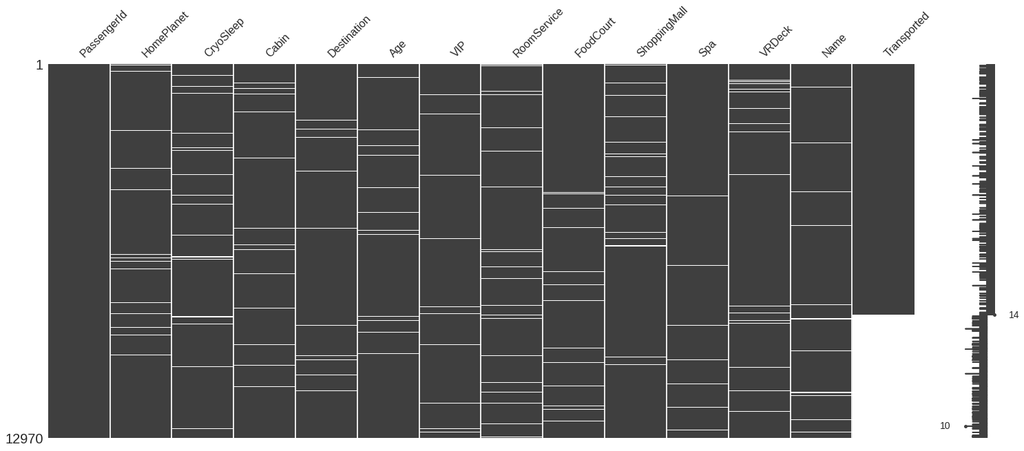

```python
import missingno as msno
msno.matrix(all_data)
```

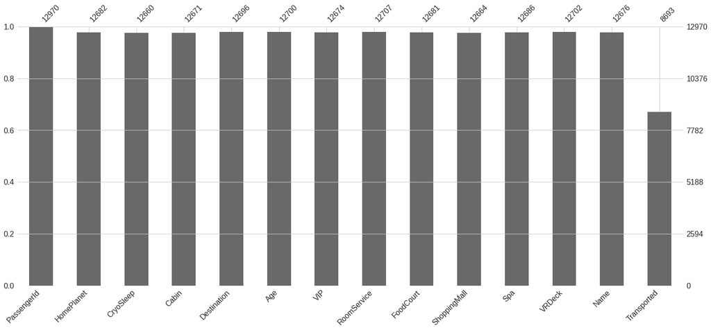

```python
msno.bar(all_data)
```

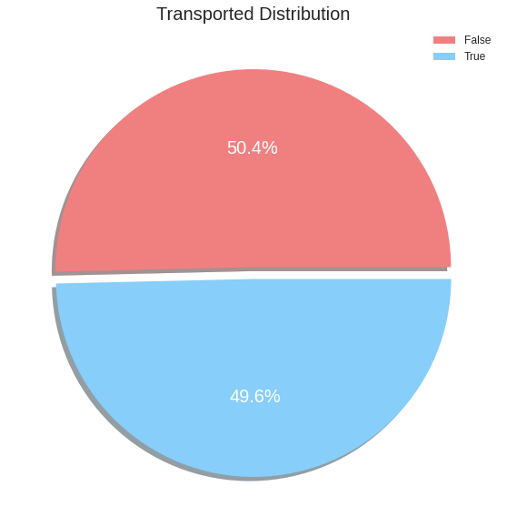

```python
# Target 컬럼(Transported) 시각화

plt.subplots(figsize=(25, 10))
plt.pie(train.Transported.value_counts(),
        shadow=True, explode=[.03,.03],
        autopct='%1.1f%%',
        textprops={'fontsize': 20, 'color': 'white'})
plt.title('Transported Distribution', size=20)
plt.legend(['False', 'True'], loc='best', fontsize=12)
plt.show()
```

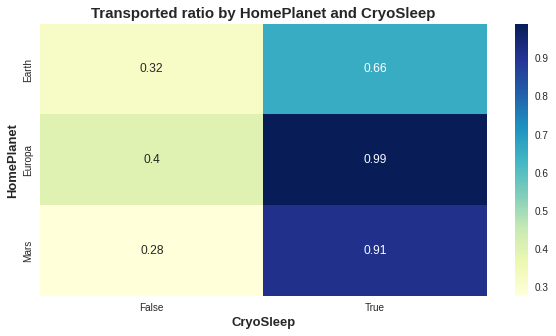

| CryoSleep | HomePlanet Transported | Earth | Europa | Mars | All |
| --- | --- | --- | --- | --- | --- |
| False | False | 2109 | 697 | 757 | 3563 |
|  | True | 997 | 465 | 290 | 1752 |
| True | False | 475 | 10 | 59 | 544 |
|  | True | 907 | 901 | 610 | 2418 |
| All |  | 4488 | 2073 | 1716 | 8277 |

```python
# 히트맵을 이용한 시각화
# 데이터의 비율을 표시
# Heatmap can visualize continuous values (or binary variables) in categories and categories.
plt.subplots(figsize=(10, 5))
g = sns.heatmap(train.pivot_table(index='HomePlanet',
                                  columns='CryoSleep',
                                  values='Transported'), annot=True, cmap="YlGnBu")
# 제목, x,y레이블
g.set_title('Transported ratio by HomePlanet and CryoSleep',
            weight='bold', size=15)
g.set_xlabel('CryoSleep',
             weight='bold', size=13)

g.set_ylabel('HomePlanet',
             weight='bold', size=13)
plt.show()


pd.crosstab([train.CryoSleep,
             train.Transported],
            train.HomePlanet,margins=True).style.background_gradient()
```

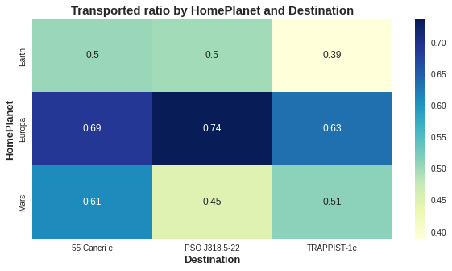

| Destination | HomePlanet Transported | Earth | Europa | Mars | All |
| --- | --- | --- | --- | --- | --- |
| 55 Cancri e | False | 342 | 275 | 75 | 692 |
|  | True | 348 | 611 | 118 | 1077 |
| PSO J318.5-22 | False | 357 | 5 | 27 | 389 |
|  | True | 355 | 14 | 22 | 391 |
| TRAPPIST-1e | False | 1894 | 434 | 720 | 3048 |
|  | True | 1207 | 755 | 755 | 2717 |
| All |  | 4503 | 2094 | 1717 | 8314 |

```python
# Target의 데이터의 전체에서 True가 가지는 비율 시각화
# y축 : HomePlanet, x축 : Destination, 값 : Transported
plt.subplots(figsize=(10, 5))
g = sns.heatmap(train.pivot_table(index='HomePlanet',
                                  columns='Destination',
                                  values='Transported'),
                annot=True, cmap="YlGnBu")
g.set_title('Transported ratio by HomePlanet and Destination',
            weight='bold', size=15)
g.set_xlabel('Destination',
             weight='bold', size=13)
g.set_ylabel('HomePlanet',
             weight='bold', size=13)
plt.show()

pd.crosstab([train.Destination, train.Transported],
            train.HomePlanet,margins=True).style.background_gradient()
```

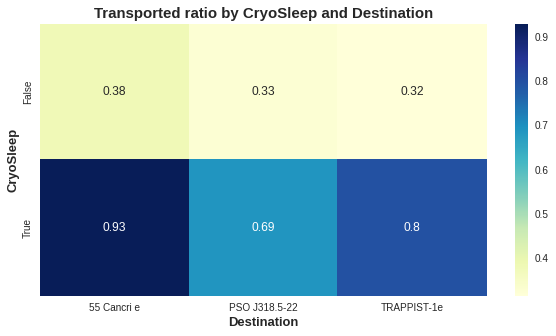

| CryoSleep | Destination Transported | 55 Cancri e | PSO J318.5-22 | TRAPPIST-1e | All |
| --- | --- | --- | --- | --- | --- |
| False | False | 630 | 265 | 2669 | 3564 |
|  | True | 387 | 129 | 1229 | 1745 |
| True | False | 53 | 119 | 379 | 551 |
|  | True | 686 | 264 | 1488 | 2438 |
| All |  | 1756 | 777 | 5765 | 8298 |

```python
plt.subplots(figsize=(10, 5))
g = sns.heatmap(train.pivot_table(index='CryoSleep',
                                  columns='Destination',
                                  values='Transported'),
                annot=True, cmap="YlGnBu")
g.set_title('Transported ratio by CryoSleep and Destination',
            weight='bold', size=15)
g.set_xlabel('Destination',
             weight='bold', size=13)
g.set_ylabel('CryoSleep',
             weight='bold', size=13)
plt.show()

pd.crosstab([train.CryoSleep, train.Transported],
            train.Destination,margins=True).style.background_gradient()
```

### 결측치 채우기

```python
# CryoSleep의 값 빈도 확인
print( all_data['CryoSleep'].value_counts() )  # 다수의 값이 Fasle를 가진다.
```

```
False    8079
True     4581
Name: CryoSleep, dtype: int64
```

```python
# 결측치 처리. 범주의 형일 경우, 다수의 값으로 채운다.
# Replace categorical variables with specific values (False, None) or freeest values.
all_data['CryoSleep'].fillna(False, inplace=True)
all_data['Cabin'].fillna('None', inplace=True)
all_data['VIP'].fillna(all_data.VIP.mode()[0], inplace=True)
all_data['HomePlanet'].fillna(all_data.HomePlanet.mode()[0], inplace=True)
all_data['Destination'].fillna(all_data.Destination.mode()[0], inplace=True)

# 연속형 변수의 결측치는 0 또는 평균으로 대치시킨다.
all_data['Age'].fillna(all_data.Age.mean(), inplace=True)
all_data[['RoomService', 'FoodCourt', 'ShoppingMall', 'Spa', 'VRDeck']] =\
                all_data[['RoomService', 'FoodCourt', 'ShoppingMall', 'Spa', 'VRDeck']].fillna(0)
```

```python
# As mentioned earlier, create a new variable by decomposing strings in Cabin and PassengerId.
all_data['Deck'] = all_data.Cabin.apply(lambda x:str(x)[:1])
all_data['Side'] = all_data.Cabin.apply(lambda x:str(x)[-1:])
all_data['PassengerGroup'] = all_data['PassengerId'].apply(lambda x: x.split('_')[0])
all_data['PassengerNo'] = all_data['PassengerId'].apply(lambda x: x.split('_')[1])

# 컬럼에서의 다양한 서비스와 관련 있는 내용을 이용하여 새로운 변수를 생성.
all_data['TotalSpend'] = all_data['RoomService'] + all_data['FoodCourt'] +\
                              all_data['ShoppingMall'] + all_data['Spa'] + all_data['VRDeck']
all_data['PctRoomService'] = all_data['RoomService']/all_data['TotalSpend']
all_data['PctFoodCourt'] = all_data['FoodCourt']/all_data['TotalSpend']
all_data['PctShoppingMall'] = all_data['ShoppingMall']/all_data['TotalSpend']
all_data['PctSpa'] = all_data['Spa']/all_data['TotalSpend']
all_data['PctVRDeck'] = all_data['VRDeck']/all_data['TotalSpend']

# Create new variables by dividing age groups.
all_data['AgeBin'] = 7
for i in range(6):
    all_data.loc[(all_data.Age >= 10*i) & (all_data.Age < 10*(i + 1)), 'AgeBin'] = i
```

```python
# 생성된 변수의 결측치가 있다면 이를 0으로 결측치 처리
fill_cols = ['PctRoomService', 'PctFoodCourt', 'PctShoppingMall', 'PctSpa', 'PctVRDeck']
all_data[fill_cols] = all_data[fill_cols].fillna(0)
```

### 변수 제거

```python
all_data.drop(['PassengerId', 'Name', 'Cabin'], axis=1, inplace=True)
```

### 라벨 인코딩

```python
for col in all_data.columns[all_data.dtypes == object]:
    if col != 'Transported':
        le = LabelEncoder()
        all_data[col] = le.fit_transform(all_data[col])

all_data['CryoSleep'] = all_data['CryoSleep'].astype('int')
all_data['VIP'] = all_data['VIP'].astype('int')
```

### 데이터 나누기

```python
train, X_test = all_data.iloc[ :train.shape[0]], all_data.iloc[train.shape[0]:].drop(['Transported'], axis=1)
X_train, y_train = train.drop(['Transported'], axis=1), train['Transported']
```

### 05. 모델 구축 및 예측

목차로 이동하기

- pycaret를 활용.

```python
s = setup(data=train,
          session_id=7010,
          target='Transported',
          train_size=0.99,
          fold_strategy='stratifiedkfold',
          fold=5,
          fold_shuffle=True,
          silent=True,
          ignore_low_variance=True,
          remove_multicollinearity = True,
          normalize = True,
          normalize_method = 'robust',)
```

|  | Description | Value |
| --- | --- | --- |
| 0 | session_id | 7010 |
| 1 | Target | Transported |
| 2 | Target Type | Binary |
| 3 | Label Encoded | False: 0, True: 1 |
| 4 | Original Data | (8693, 22) |
| 5 | Missing Values | False |
| 6 | Numeric Features | 13 |
| 7 | Categorical Features | 8 |
| 8 | Ordinal Features | False |
| 9 | High Cardinality Features | False |
| 10 | High Cardinality Method | None |
| 11 | Transformed Train Set | (8606, 45) |
| 12 | Transformed Test Set | (87, 45) |
| 13 | Shuffle Train-Test | True |
| 14 | Stratify Train-Test | False |
| 15 | Fold Generator | StratifiedKFold |
| 16 | Fold Number | 5 |
| 17 | CPU Jobs | -1 |
| 18 | Use GPU | False |
| 19 | Log Experiment | False |
| 20 | Experiment Name | clf-default-name |
| 21 | USI | 3767 |
| 22 | Imputation Type | simple |
| 23 | Iterative Imputation Iteration | None |
| 24 | Numeric Imputer | mean |
| 25 | Iterative Imputation Numeric Model | None |
| 26 | Categorical Imputer | constant |
| 27 | Iterative Imputation Categorical Model | None |
| 28 | Unknown Categoricals Handling | least_frequent |
| 29 | Normalize | True |
| 30 | Normalize Method | robust |
| 31 | Transformation | False |
| 32 | Transformation Method | None |
| 33 | PCA | False |
| 34 | PCA Method | None |
| 35 | PCA Components | None |
| 36 | Ignore Low Variance | True |
| 37 | Combine Rare Levels | False |
| 38 | Rare Level Threshold | None |
| 39 | Numeric Binning | False |
| 40 | Remove Outliers | False |
| 41 | Outliers Threshold | None |
| 42 | Remove Multicollinearity | True |
| 43 | Multicollinearity Threshold | 0.9 |
| 44 | Remove Perfect Collinearity | True |
| 45 | Clustering | False |
| 46 | Clustering Iteration | None |
| 47 | Polynomial Features | False |
| 48 | Polynomial Degree | None |
| 49 | Trignometry Features | False |
| 50 | Polynomial Threshold | None |
| 51 | Group Features | False |
| 52 | Feature Selection | False |
| 53 | Feature Selection Method | classic |
| 54 | Features Selection Threshold | None |
| 55 | Feature Interaction | False |
| 56 | Feature Ratio | False |
| 57 | Interaction Threshold | None |
| 58 | Fix Imbalance | False |
| 59 | Fix Imbalance Method | SMOTE |

```python
# 모델을 비교하여 최적의 모델 4개를 선택.
top4 = compare_models(n_select=4)
```

|  | Model | Accuracy | AUC | Recall | Prec. | F1 | Kappa | MCC | TT (Sec) |
| --- | --- | --- | --- | --- | --- | --- | --- | --- | --- |
| lightgbm | Light Gradient Boosting Machine | 0.8076 | 0.8998 | 0.8141 | 0.8058 | 0.8098 | 0.6151 | 0.6154 | 0.388 |
| gbc | Gradient Boosting Classifier | 0.8012 | 0.8949 | 0.8360 | 0.7835 | 0.8088 | 0.6022 | 0.6037 | 2.176 |
| rf | Random Forest Classifier | 0.7983 | 0.8816 | 0.7732 | 0.8162 | 0.7940 | 0.5967 | 0.5977 | 1.646 |
| ada | Ada Boost Classifier | 0.7963 | 0.8777 | 0.8418 | 0.7736 | 0.8061 | 0.5924 | 0.5950 | 0.504 |
| lr | Logistic Regression | 0.7936 | 0.8800 | 0.8293 | 0.7759 | 0.8017 | 0.5871 | 0.5885 | 1.712 |
| et | Extra Trees Classifier | 0.7907 | 0.8639 | 0.7610 | 0.8114 | 0.7852 | 0.5816 | 0.5829 | 1.372 |
| ridge | Ridge Classifier | 0.7898 | 0.0000 | 0.8506 | 0.7603 | 0.8028 | 0.5793 | 0.5836 | 0.066 |
| lda | Linear Discriminant Analysis | 0.7898 | 0.8739 | 0.8506 | 0.7603 | 0.8028 | 0.5793 | 0.5836 | 0.098 |
| knn | K Neighbors Classifier | 0.7770 | 0.8501 | 0.7658 | 0.7856 | 0.7755 | 0.5541 | 0.5543 | 0.662 |
| nb | Naive Bayes | 0.7727 | 0.8471 | 0.8945 | 0.7211 | 0.7984 | 0.5447 | 0.5616 | 0.086 |
| dt | Decision Tree Classifier | 0.7516 | 0.7515 | 0.7621 | 0.7486 | 0.7553 | 0.5031 | 0.5032 | 0.154 |
| svm | SVM - Linear Kernel | 0.7237 | 0.0000 | 0.7901 | 0.7166 | 0.7414 | 0.4468 | 0.4642 | 0.206 |
| qda | Quadratic Discriminant Analysis | 0.5085 | 0.5090 | 0.4189 | 0.5315 | 0.4490 | 0.0179 | 0.0222 | 0.072 |
| dummy | Dummy Classifier | 0.5031 | 0.5000 | 1.0000 | 0.5031 | 0.6694 | 0.0000 | 0.0000 | 0.042 |

```python
print(top4[0])
```

```
LGBMClassifier(boosting_type='gbdt', class_weight=None, colsample_bytree=1.0,
               importance_type='split', learning_rate=0.1, max_depth=-1,
               min_child_samples=20, min_child_weight=0.001, min_split_gain=0.0,
               n_estimators=100, n_jobs=-1, num_leaves=31, objective=None,
               random_state=7010, reg_alpha=0.0, reg_lambda=0.0, silent='warn',
               subsample=1.0, subsample_for_bin=200000, subsample_freq=0)
```

```python
# 추가 필요 라이브러리 설치
!pip install scikit-optimize
!pip install tune-sklearn ray[tune]
!pip install hpbandster ConfigSpace
!pip install optuna
```

[output not shown]

```python
import optuna
```

```python
# 참고용
# catboost_best = create_model('catboost', nan_mode= 'Min',
#                          eval_metric='Logloss',
#                          iterations=1000,
#                          sampling_frequency='PerTree',
#                          leaf_estimation_method='Newton',
#                          grow_policy='SymmetricTree',
#                          penalties_coefficient=1,
#                          boosting_type='Plain',
#                          model_shrink_mode='Constant',
#                          feature_border_type='GreedyLogSum',
#                          l2_leaf_reg=3,
#                          random_strength=1,
#                          rsm=1,
#                          boost_from_average=False,
#                          model_size_reg=0.5,
#                          subsample=0.800000011920929,
#                          use_best_model=False,
#                          class_names=[0, 1],
#                          depth=6,
#                          posterior_sampling=False,
#                          border_count=254,
#                          classes_count=0,
#                          auto_class_weights='None',
#                          sparse_features_conflict_fraction=0,
#                          leaf_estimation_backtracking='AnyImprovement',
#                          best_model_min_trees=1,
#                          model_shrink_rate=0,
#                          min_data_in_leaf=1,
#                          loss_function='Logloss',
#                          learning_rate=0.02582800015807152,
#                          score_function='Cosine',
#                          task_type='CPU',
#                          leaf_estimation_iterations=10,
#                          bootstrap_type='MVS',
#                          max_leaves=64)
```

```python
# 성능이 좋은 특정 모델 지정.
lightgbm_best = create_model('lightgbm', nan_mode= 'Min',
                          eval_metric='Logloss',
                          iterations=1000,
                          sampling_frequency='PerTree',
                          leaf_estimation_method='Newton',
                          grow_policy='SymmetricTree',
                          penalties_coefficient=1,
                          model_shrink_mode='Constant',
                          feature_border_type='GreedyLogSum',
                          l2_leaf_reg=3,
                          random_strength=1,
                          rsm=1,
                          boost_from_average=False,
                          model_size_reg=0.5,
                          subsample=0.800000011920929,
                          use_best_model=False,
                          class_names=[0, 1],
                          depth=6,
                          posterior_sampling=False,
                          border_count=254,
                          classes_count=0,
                          auto_class_weights='None',
                          sparse_features_conflict_fraction=0,
                          leaf_estimation_backtracking='AnyImprovement',
                          best_model_min_trees=1,
                          model_shrink_rate=0,
                          min_data_in_leaf=1,
                          loss_function='Logloss',
                          learning_rate=0.02582800015807152,
                          score_function='Cosine',
                          leaf_estimation_iterations=10,
                          bootstrap_type='MVS',
                          max_leaves=64
)
```

| Fold | Accuracy | AUC | Recall | Prec. | F1 | Kappa | MCC |
| --- | --- | --- | --- | --- | --- | --- | --- |
| 0 | 0.7938 | 0.8938 | 0.8048 | 0.7894 | 0.7970 | 0.5876 | 0.5877 |
| 1 | 0.8100 | 0.9013 | 0.8418 | 0.7933 | 0.8168 | 0.6198 | 0.6210 |
| 2 | 0.8094 | 0.8926 | 0.8303 | 0.7989 | 0.8143 | 0.6187 | 0.6192 |
| 3 | 0.7955 | 0.8912 | 0.8464 | 0.7700 | 0.8064 | 0.5907 | 0.5936 |
| 4 | 0.8181 | 0.9057 | 0.8395 | 0.8069 | 0.8229 | 0.6361 | 0.6367 |
| Mean | 0.8054 | 0.8969 | 0.8326 | 0.7917 | 0.8115 | 0.6106 | 0.6117 |
| Std | 0.0093 | 0.0056 | 0.0148 | 0.0124 | 0.0090 | 0.0186 | 0.0183 |

```python
# 다음과 같이 모델의 미세 조정이 가능.
# catboost = tune_model(create_model('catboost'), choose_better = True, n_iter = 20)
# catboost2 = tune_model(create_model('catboost'), optimize='Accuracy',
#                        search_library='scikit-optimize', search_algorithm='bayesian',
#                        choose_better = True, n_iter = 20)
# catboost3 = tune_model(create_model('catboost'), optimize='Accuracy',
#                        search_library='tune-sklearn', search_algorithm='bayesian',
#                        choose_better = True, n_iter = 20)
# catboost4 = tune_model(create_model('catboost'), optimize='Accuracy',
#                        search_library='tune-sklearn', search_algorithm='hyperopt',
#                        choose_better = True, n_iter = 20)
# catboost5 = tune_model(create_model('catboost'), optimize='Accuracy',
#                        search_library='tune-sklearn', search_algorithm='optuna',
#                        choose_better = True, n_iter = 20)
# catboost6 = tune_model(create_model('catboost'), optimize='Accuracy',
#                        search_library='optuna', search_algorithm='tpe',
#                        choose_better = True, n_iter = 20)
```

### 앙상블(Ensemble)

```python
# tuned_top4 = [tune_model(i) for i in top4]
# blender_top4 = blend_models(estimator_list=tuned_top4)
```

```python
# 지정된 모델을 이용하여 예측을 수행
df_pred = predict_model(lightgbm_best, X_test)
y_pred = df_pred.loc[:, ['Label']]
```

```python
submission['Transported'] = y_pred
submission.to_csv('submission.csv', index=False)
submission
```

|  | PassengerId | Transported |
| --- | --- | --- |
| 0 | 0013_01 | True |
| 1 | 0018_01 | False |
| 2 | 0019_01 | True |
| 3 | 0021_01 | True |
| 4 | 0023_01 | False |
| ... | ... | ... |
| 4272 | 9266_02 | True |
| 4273 | 9269_01 | False |
| 4274 | 9271_01 | True |
| 4275 | 9273_01 | True |
| 4276 | 9277_01 | True |

4277 rows × 2 columns

### 제출 결과 : 0.80454

### REF

- gc 에 대해 이해해 보기
  - https://medium.com/dmsfordsm/garbage-collection-in-python-777916fd3189